# San Juan escapement 2024 (PRELIM)

South Coast StA

Last update: 2025-02-27

# 1 **Sockeye**

Three complete surveys conducted over 2-3 days per survey were conducted for in 2023. They were likely too late for an accurate SK estimate and did not include Fairy Lake where there is the potential for some lake spawners.

## 1.1 Area 20 raw vs expanded counts

Counts are expanded for % population estimated and/or observer efficiency, depending on survey conditions.

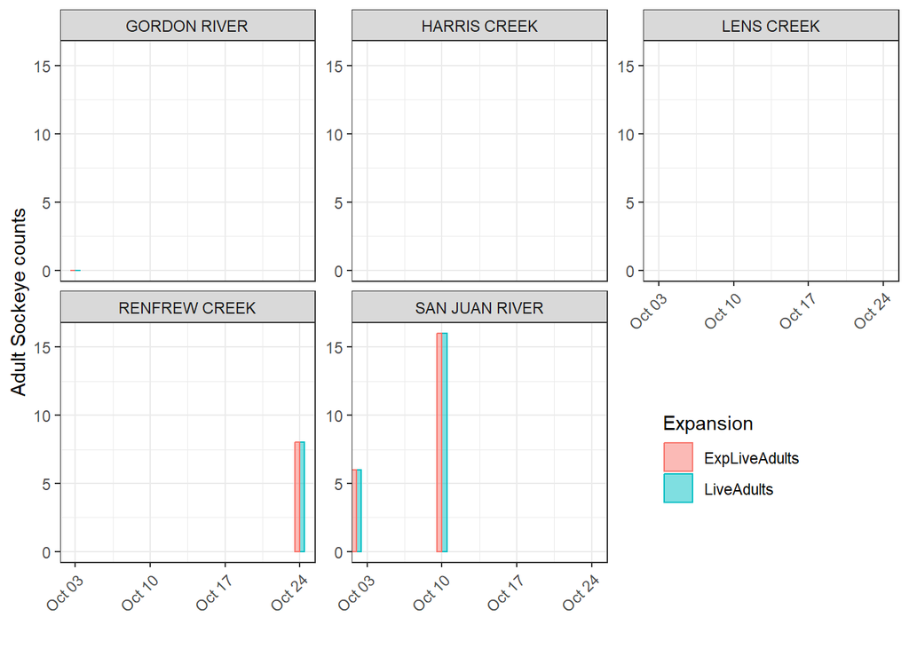

Figure: Raw live Adult Sockeye counts (blue) and expanded for OE (pink).

## 1.2 Counts & environmentals

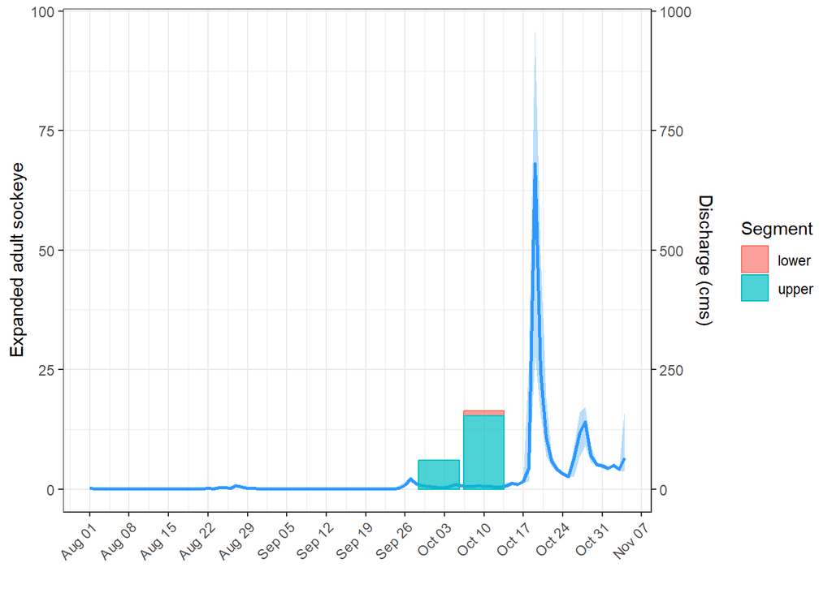

Figure: Sockeye raw counts (live adults) and water levels (blue line) in the San Juan mainstem.

## 1.3 Behaviour & carcasses

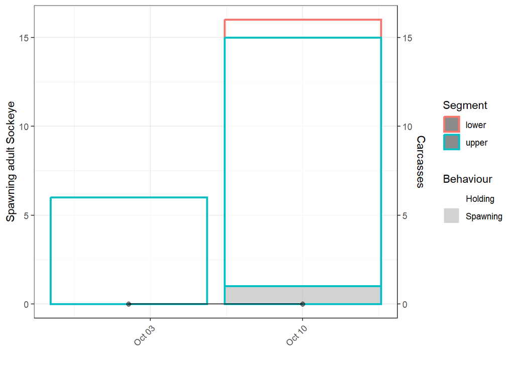

Figure: Raw live adult Sockeye (bars) and carcasses (black line) in the San Juan mainstem. Bar fill colour indicates behaviour (spawning=gray, holding=white) while bar outline colour indicates river segment (lower=pink, mid=green, upper=blue). Note Oct 3/4 “mid” section was covered within upper and lower segments.

## 1.4 Swim & fence counts

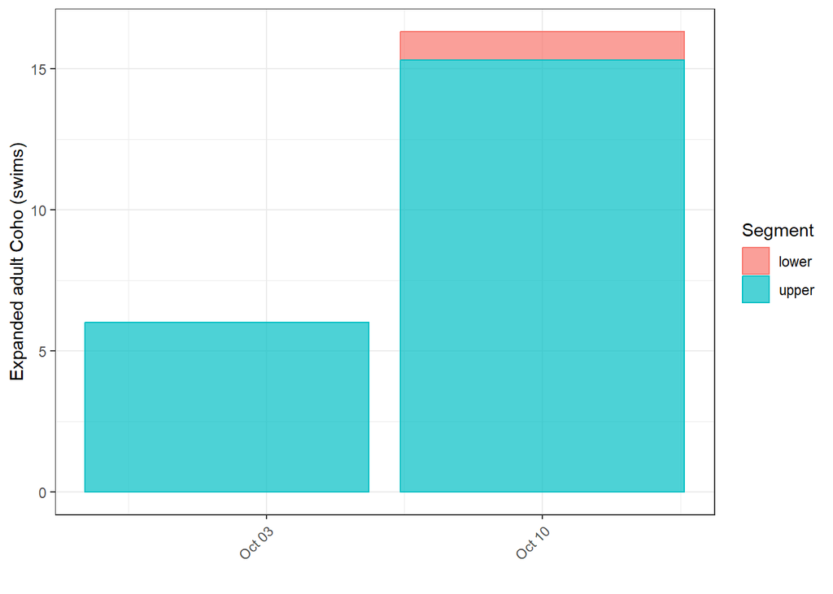

Figure: Sockeye swim counts (raw adults) in the San Juan mainstem relative to cumulative fence counts (black line). If no black line, then no Sockeye were counted through the fence this year.

## 1.5 Tributaries

Table: Sockeye counts (raw live and dead) for San Juan tributaries (Renfrew, Lens, Harris) and Gordon River in 2023.

| trib_status | system | date | live_adults | dead_adults |
| --- | --- | --- | --- | --- |
| San Juan mainstem | San Juan River | 2024-10-02 | 6 | 0 |
| San Juan mainstem | San Juan River | 2024-10-10 | 16 | 0 |
| San Juan trib | Renfrew Creek | 2024-10-24 | 8 | 0 |

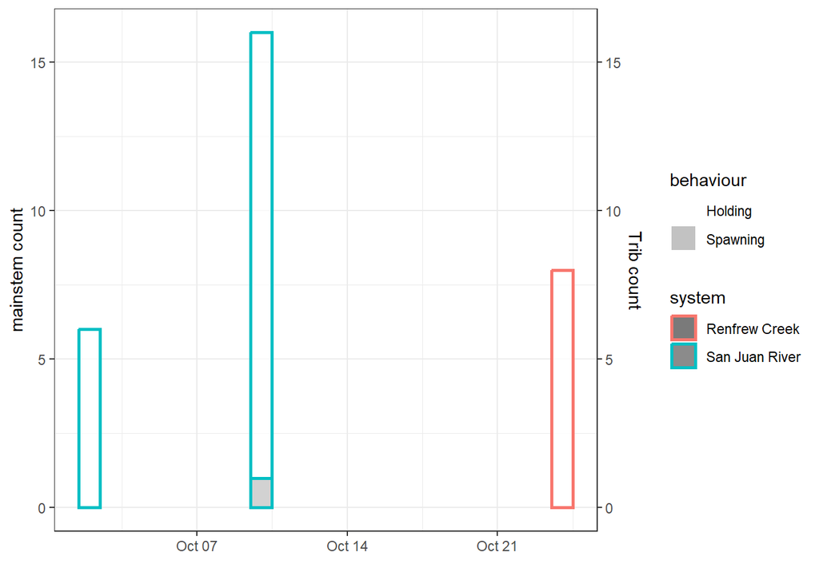

Figure: Mainstem and trib counts for Sockeye adults (raw).

## 1.6 Area 20 preliminary escapement estimates (PL+D)

Table: San Juan raw swim data (raw and expanded live and dead) for Sockeye.

| ShortSpecies | Section_AreaInspected | SDate | WaterTemperature | WaterClarity | LiveAdults | DeadAdults | LiveJacks | DeadJacks | ExpLiveAdults | ExpDeadAdults | ExpLiveJacks | ExpDeadJacks | OverallReliability | EstPctSeen |
| --- | --- | --- | --- | --- | --- | --- | --- | --- | --- | --- | --- | --- | --- | --- |
| SK | GORDON RIVER | 2024-10-03 | 99.0 | 3 - 5 m or to Bottom | 0 | NA | NA | NA | 0 | NA | NA | NA | H | 1 |
| SK | HARRIS CREEK | 2024-10-07 | 9.5 | 3 - 5 m or to Bottom | NA | NA | NA | NA | NA | NA | NA | NA | NA | NA |
| SK | LENS CREEK | 2024-10-09 | 10.0 | 3 - 5 m or to Bottom | NA | NA | NA | NA | NA | NA | NA | NA | NA | NA |
| SK | RENFREW CREEK | 2024-10-24 | 8.0 | 3 - 5 m or to Bottom | 8 | 0 | NA | NA | 8 | NA | NA | NA | M | 1 |
| SK | SAN JUAN RIVER | 2024-10-02 | 6.0 | 3 - 5 m or to Bottom | 6 | 0 | 0 | NA | 6 | NA | NA | NA | H | 1 |
| SK | SAN JUAN RIVER | 2024-10-10 | 9.5 | 3 - 5 m or to Bottom | 16 | NA | NA | NA | 16 | NA | NA | NA | M | 1 |
| SK | SAN JUAN RIVER | 2024-10-25 | 8.0 | 3 - 5 m or to Bottom | NA | NA | NA | NA | NA | NA | NA | NA | M | 1 |

Table: Escapement estimates for each system. San Juan mainstem surveys were rolled up based on mid-point date for each of 3 complete survey events, and then the PL+D was selected based on the 3 survey events.

[output not shown]

### 1.6.1 Estimate decision:

For 2024 estimates used PL+D. No SK counted through the fence. No accounting needed for tribs as none observed in Harris/Lens (and Renfrew d/s of SJ survey area).

## 1.7 2024 compared to historical abundance

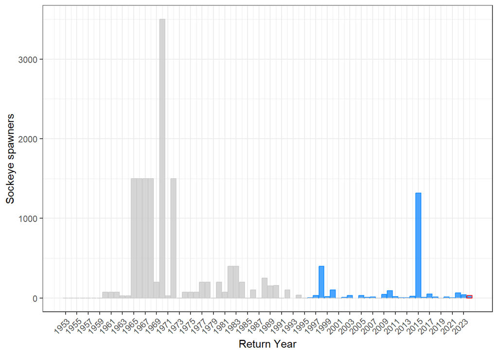

Figure: 2024 preliminary adult Sockeye escapement estimate (red outline) for entire San Juan system (including tributaries) relative to historical adult (blue) and unspecified (gray) escapement estimates. Gaps indicate years without estimates.

# 2 **Coho**

## 2.1 Area 20 raw vs expanded counts

Counts are expanded for % population estimated and/or observer efficiency, depending on survey conditions.

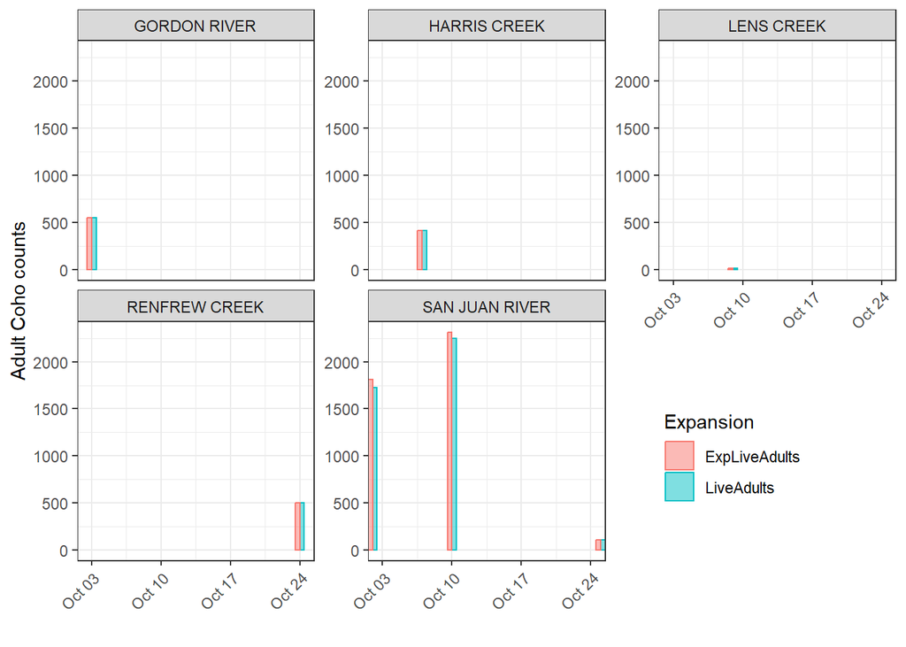

Figure: Raw live Adult Coho counts (blue) and expanded for OE (pink).

## 2.2 Counts & environmentals

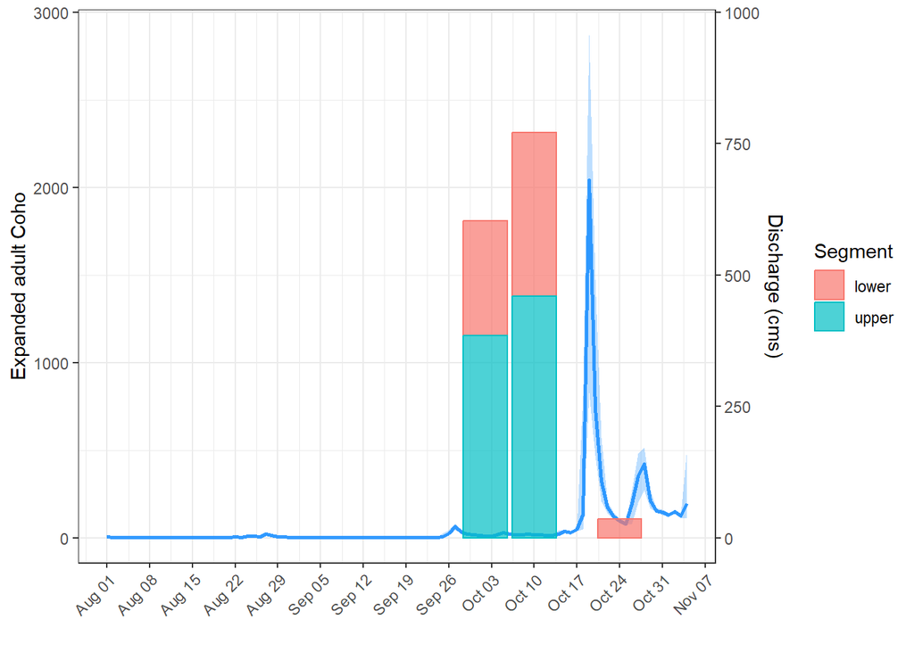

Figure: Coho counts (expanded live adults) and water levels (blue line) in the San Juan mainstem.

## 2.3 Behaviour & carcasses

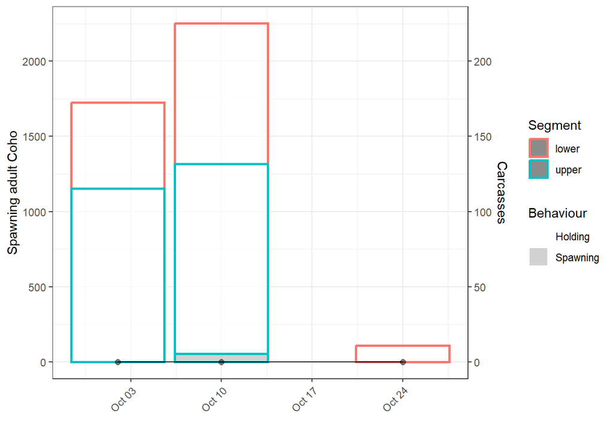

Figure: Expanded live adult Coho (bars) and carcasses (black line) in the San Juan mainstem. Bar fill colur indicates behaviour (spawning=gray, holding=white) while bar outline colour indicates river segment (lower=pink, mid=green, upper=blue).

## 2.4 Swim & fence counts

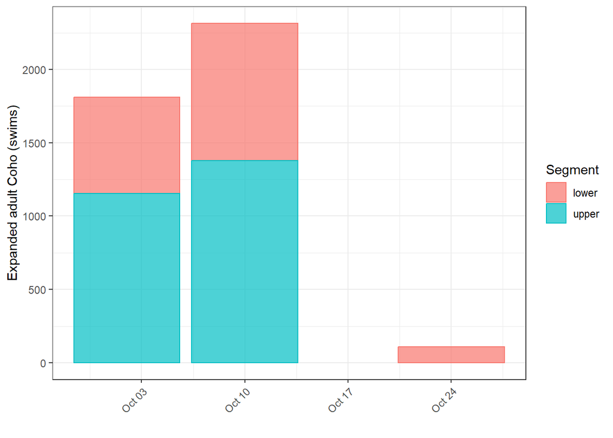

Figure: Coho swim counts (raw adults) in the San Juan mainstem relative to cumulative fence counts (black line). If no black line, then no coho were counted through the fence this year.

## 2.5 Tributaries

| trib_status | system | date | live_adults | dead_adults |
| --- | --- | --- | --- | --- |
| Other Area 20 | Gordon River | 2024-10-03 | 547 | 0 |
| San Juan mainstem | San Juan River | 2024-10-02 | 1726 | 0 |
| San Juan mainstem | San Juan River | 2024-10-10 | 2251 | 0 |
| San Juan mainstem | San Juan River | 2024-10-24 | 108 | 0 |
| San Juan trib | Harris Creek | 2024-10-07 | 415 | 0 |
| San Juan trib | Lens Creek | 2024-10-09 | 10 | 0 |
| San Juan trib | Renfrew Creek | 2024-10-24 | 498 | 0 |

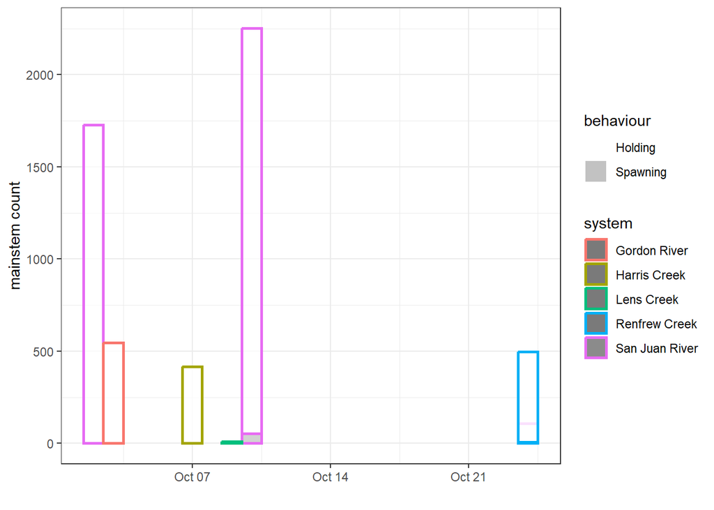

Figure: Mainstem and trib counts for Coho adults (unexpanded).

## 2.6 Area 20 preliminary escapement estimates (PL+D)

Table: Area 20 raw swim data (raw and expanded live and dead) for Coho.

| ShortSpecies | Section_AreaInspected | SDate | WaterTemperature | WaterClarity | LiveAdults | DeadAdults | LiveJacks | DeadJacks | ExpLiveAdults | ExpDeadAdults | ExpLiveJacks | ExpDeadJacks | OverallReliability | EstPctSeen |
| --- | --- | --- | --- | --- | --- | --- | --- | --- | --- | --- | --- | --- | --- | --- |
| CO | GORDON RIVER | 2024-10-03 | 99.0 | 3 - 5 m or to Bottom | 547 | NA | 45 | NA | 547 | NA | NA | NA | H | 1 |
| CO | HARRIS CREEK | 2024-10-07 | 9.5 | 3 - 5 m or to Bottom | 415 | NA | 32 | NA | 415 | NA | NA | NA | H | 1 |
| CO | LENS CREEK | 2024-10-09 | 10.0 | 3 - 5 m or to Bottom | 10 | NA | 1 | NA | 10 | NA | NA | NA | H | 1 |
| CO | RENFREW CREEK | 2024-10-24 | 8.0 | 3 - 5 m or to Bottom | 498 | 0 | 17 | NA | 498 | NA | NA | NA | M | 1 |
| CO | SAN JUAN RIVER | 2024-10-02 | 6.0 | 3 - 5 m or to Bottom | 1726 | 0 | 60 | NA | 1808 | NA | NA | NA | M | 1 |
| CO | SAN JUAN RIVER | 2024-10-10 | 9.5 | 3 - 5 m or to Bottom | 2251 | NA | 209 | NA | 2313 | NA | NA | NA | M | 1 |
| CO | SAN JUAN RIVER | 2024-10-25 | 8.0 | 3 - 5 m or to Bottom | 108 | NA | NA | NA | 108 | NA | NA | NA | M | 1 |

Table: Escapement estimates for each system. San Juan mainstem surveys were rolled up based on mid-point date for each of 3 complete survey events, and then the PL+D was selected based on the 3 survey events.

| ShortSpecies | SystemName | AdultRawPLD | AdultExpPLD | JackRawPLD | JackExpPLD | AdultRemovalsReco | JackRemovalsReco | FinalAdultEstimate | FinalJackEstimate |
| --- | --- | --- | --- | --- | --- | --- | --- | --- | --- |
| CO | San Juan River | 2251 | 2814 | 209 | 261 | 0 | 0 | 2814 | 261 |
| CO | Renfrew Creek | 498 | 622 | 17 | 21 | 0 | 0 | 622 | 21 |
| CO | Harris Creek | 415 | 415 | 32 | 32 | 0 | 0 | 415 | 32 |
| CO | Lens Creek | 10 | 10 | 1 | 1 | 0 | 0 | 10 | 1 |
| CO | Gordon River | 547 | 676 | 45 | 56 | 0 | 0 | 676 | 56 |

## 2.7 2024 compared to historical run timing and abundance

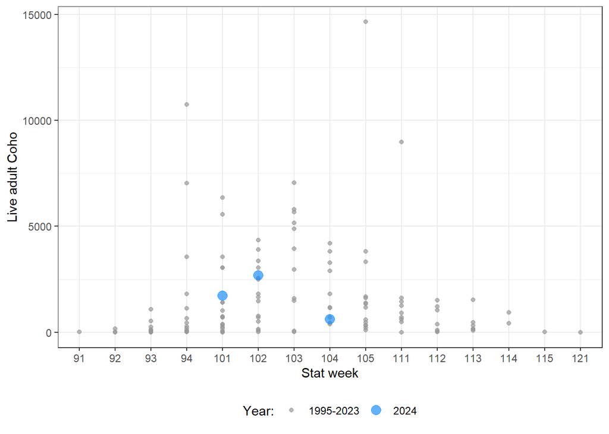

Figure: Raw swim counts (blue) from this year compared to historical raw swim counts. Stat weeks indicate the month (8=August, 12=December) and week of momth (1=first week, 2=2nd week, etc.), e.g., 81=First week of August, 91=First week of September, etc. Mainstem and tributary counts within a statweek are pooled to give run timing for the aggregate system (e.g., SJ + Harris + Lens).

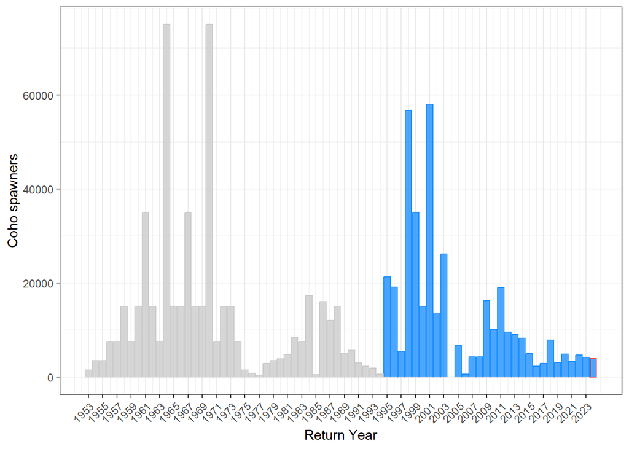

Figure: 2024 preliminary adult Coho escapement estimate (red outline) for entire San Juan system (including tributaries) relative to historical adult (blue) and unspecified (gray) escapement estimates. Gaps indicate years without estimates.

# 3 **Chum**

## 3.1 Area 20 raw vs expanded counts

Counts are expanded for % population estimated and/or observer efficiency, depending on survey conditions.

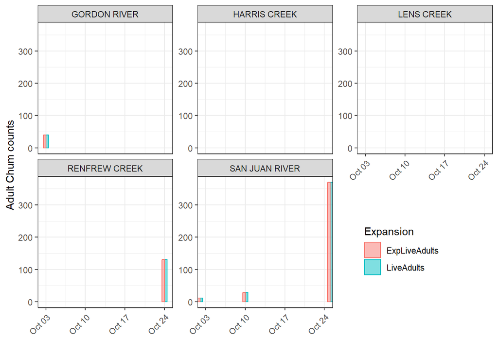

Figure: Raw live Adult Chum counts (blue) and expanded for OE (pink).

## 3.2 Counts & environmentals

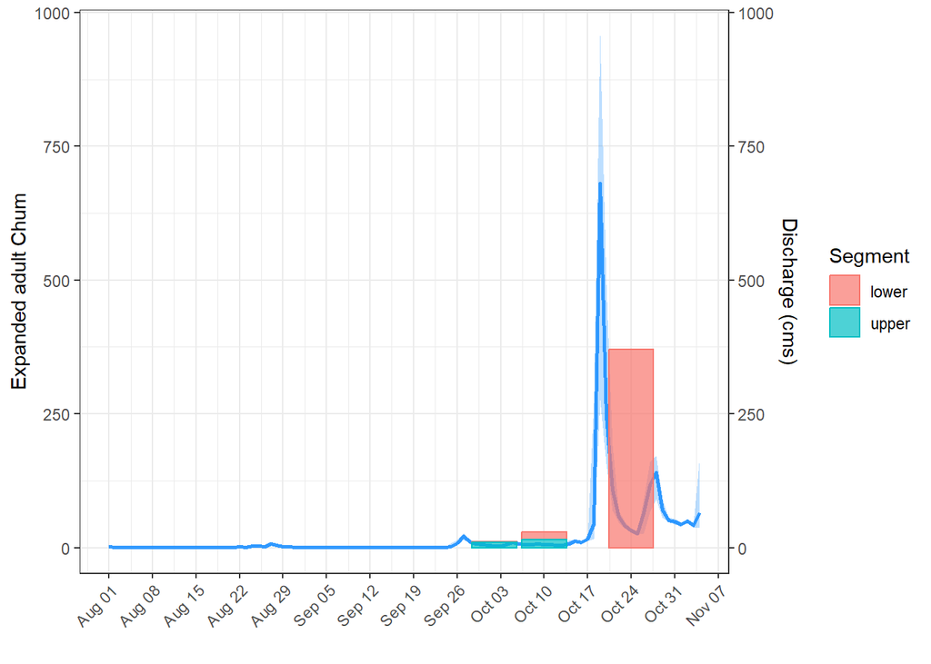

Figure: Chum counts (raw live adults) and water levels (blue line) in the San Juan mainstem.

## 3.3 Behaviour & carcasses

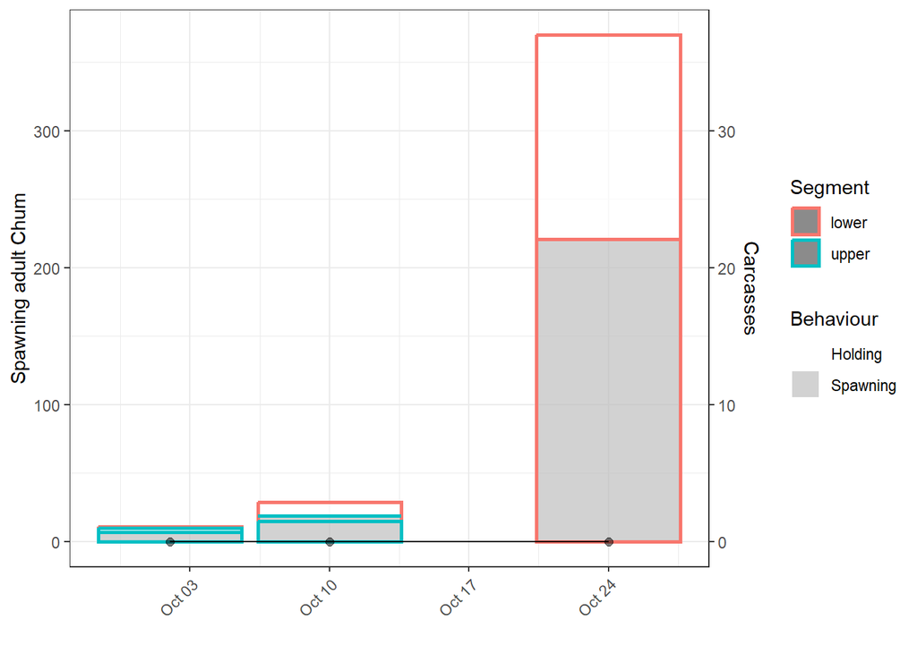

Figure: Raw live adult Chum (bars) and carcasses (black line) in the San Juan mainstem. Bar fill colour indicates behaviour (spawning=gray, holding=white) while bar outline colour indicates river segment (lower=pink, mid=green, upper=blue).

## 3.4 Swim & fence counts

No chum were passed through the fence in 2023.

## 3.5 Tributaries

Table: Chum counts (raw live and dead) for San Juan tributaries (Renfrew, Lens, Harris) and Gordon River in 2023.

| trib_status | system | date | live_adults | dead_adults |
| --- | --- | --- | --- | --- |
| Other Area 20 | Gordon River | 2024-10-03 | 40 | 0 |
| San Juan mainstem | San Juan River | 2024-10-02 | 11 | 0 |
| San Juan mainstem | San Juan River | 2024-10-10 | 29 | 0 |
| San Juan mainstem | San Juan River | 2024-10-24 | 370 | 0 |
| San Juan trib | Renfrew Creek | 2024-10-24 | 131 | 0 |

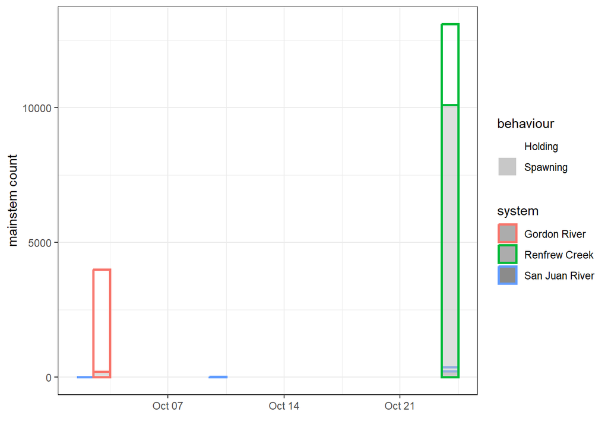

Figure: Mainstem and trib counts for Chum adults (unexpanded).

## 3.6 Area 20 preliminary escapement estimate (PL+D)

Table: San Juan swim counts (expanded live and dead) and preliminary escapement estimates for three San Juan surveys in 2023.

| ShortSpecies | Section_AreaInspected | SDate | WaterTemperature | WaterClarity | LiveAdults | DeadAdults | LiveJacks | DeadJacks | ExpLiveAdults | ExpDeadAdults | ExpLiveJacks | ExpDeadJacks | OverallReliability | EstPctSeen |
| --- | --- | --- | --- | --- | --- | --- | --- | --- | --- | --- | --- | --- | --- | --- |
| CM | GORDON RIVER | 2024-10-03 | 99.0 | 3 - 5 m or to Bottom | 40 | NA | NA | NA | 40 | NA | NA | NA | H | 1 |
| CM | HARRIS CREEK | 2024-10-07 | 9.5 | 3 - 5 m or to Bottom | NA | NA | NA | NA | NA | NA | NA | NA | NA | NA |
| CM | LENS CREEK | 2024-10-09 | 10.0 | 3 - 5 m or to Bottom | NA | NA | NA | NA | NA | NA | NA | NA | H | NA |
| CM | RENFREW CREEK | 2024-10-24 | 8.0 | 3 - 5 m or to Bottom | 131 | 0 | NA | NA | 131 | NA | NA | NA | M | 1 |
| CM | SAN JUAN RIVER | 2024-10-02 | 6.0 | 3 - 5 m or to Bottom | 11 | 0 | NA | NA | 11 | NA | NA | NA | H | 1 |
| CM | SAN JUAN RIVER | 2024-10-10 | 9.5 | 3 - 5 m or to Bottom | 29 | NA | NA | NA | 29 | NA | NA | NA | M | 1 |
| CM | SAN JUAN RIVER | 2024-10-25 | 8.0 | 3 - 5 m or to Bottom | 370 | NA | NA | NA | 370 | NA | NA | NA | M | 1 |

Table: Escapement estimates for each system. San Juan mainstem surveys were rolled up based on mid-point date for each of 3 complete survey events, and then the PL+D was selected based on the 3 survey events.

| ShortSpecies | SystemName | AdultRawPLD | AdultExpPLD | JackRawPLD | JackExpPLD | AdultRemovalsReco | JackRemovalsReco | FinalAdultEstimate | FinalJackEstimate |
| --- | --- | --- | --- | --- | --- | --- | --- | --- | --- |
| CM | San Juan River | 370 | 411 | 0 | 0 | 0 | 0 | 411 | 0 |
| CM | Renfrew Creek | 131 | 162 | 0 | 0 | 0 | 0 | 162 | 0 |
| CM | Harris Creek | 0 | 0 | 0 | 0 | 0 | 0 | 0 | 0 |
| CM | Lens Creek | 0 | 0 | 0 | 0 | 0 | 0 | 0 | 0 |
| CM | Gordon River | 40 | 42 | 0 | 0 | 0 | 0 | 42 | 0 |

### 3.6.1 Estimate decision:

For 2024 estimate used expanded PL+D of 411 adults. Did not end up adjusting the Oct 25 survey much even though it was lower-only because the 90% OE adjustment added more than enough - double-expanding added ~100 fish which seemed unlikely given timing and that these would all be in the upper section. Renfrew and Gordon also PL+D and separate from SJ. *This is subject to change; see EscBatchHardCopy report for specific estimate abundance.*

## 3.7 2024 compared to historical run timing and abundance

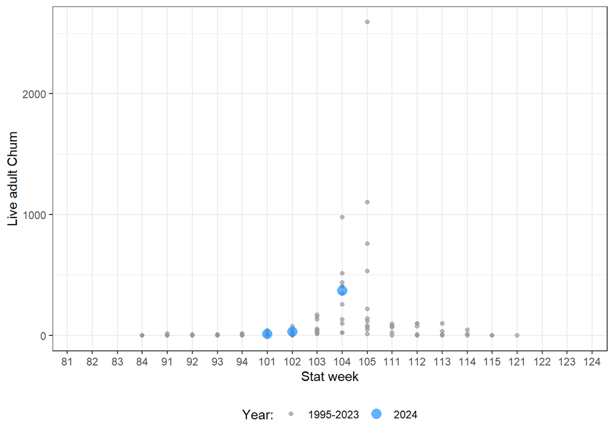

Figure: Raw swim counts (blue) from this year compared to historical raw swim counts. Stat weeks indicate the month (8=August, 12=December) and week of momth (1=first week, 2=2nd week, etc.), e.g., 81=First week of August, 91=First week of September, etc.

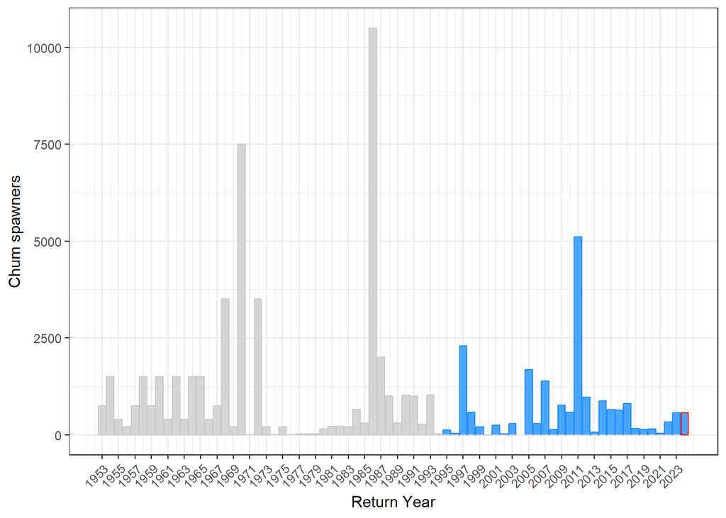

Figure: 2024 preliminary adult Chum escapement estimate (red outline) for entire San Juan system (including tributaries) relative to historical adult (blue) and unspecified (gray) escapement estimates. Gaps indicate years without estimates.

# 4 **Chinook**

Three complete surveys conducted over 2-3 days per survey were conducted for Chinook in 2023.

## 4.1 Area 20 raw vs expanded counts

Counts are expanded for % population estimated and/or observer efficiency, depending on survey conditions.

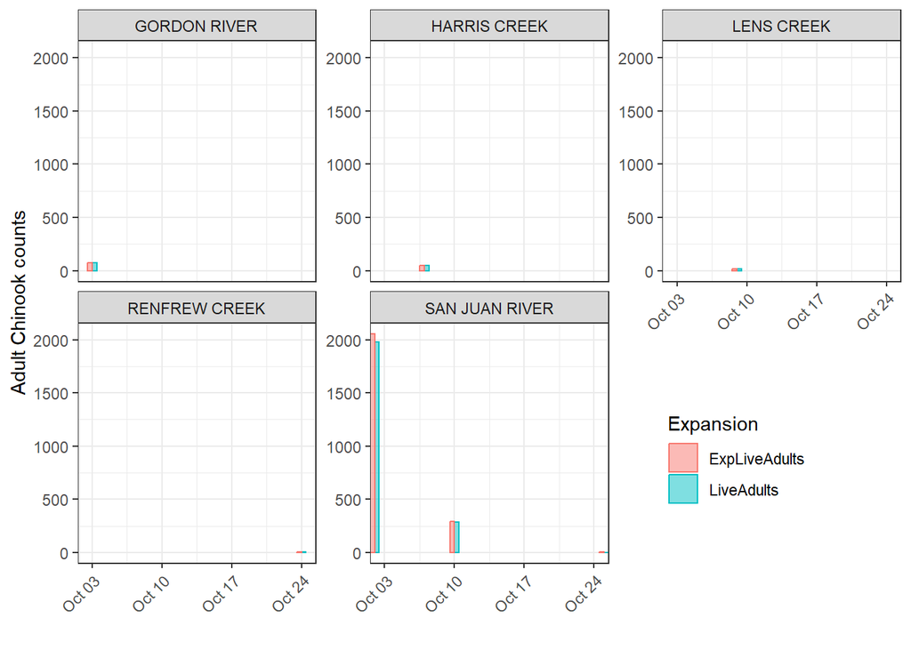

Figure: Raw live Adult Chinook counts (blue) and expanded for OE (pink).

## 4.2 Counts & environmentals

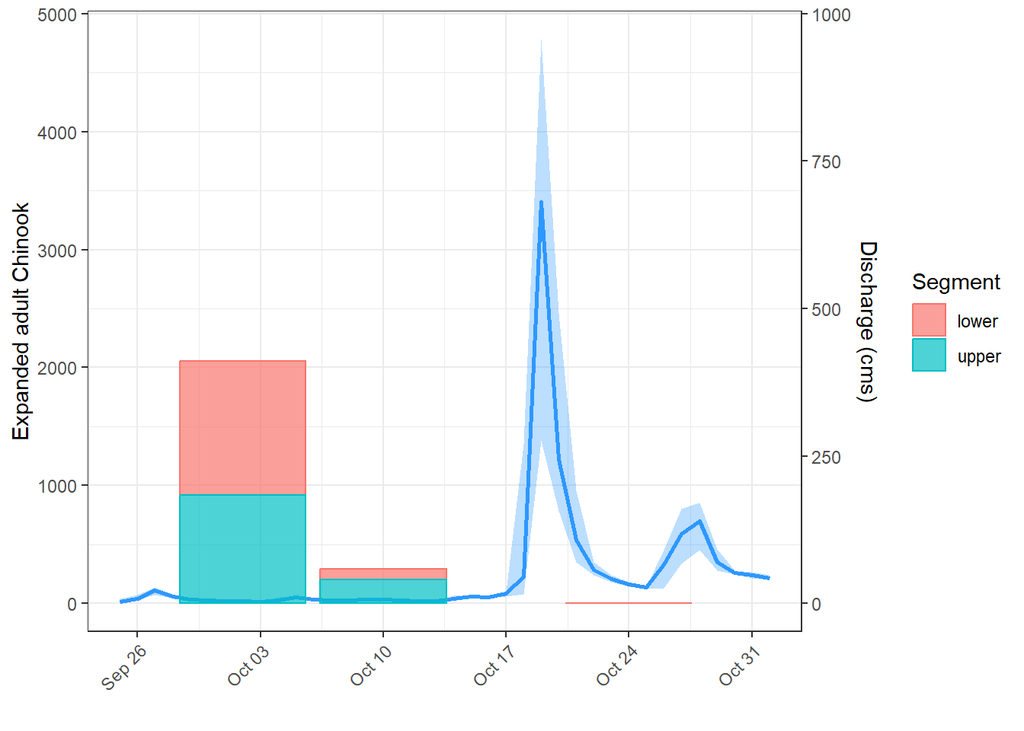

Figure: Chinook counts (expanded live adults) and water levels (blue line) in the San Juan mainstem.

## 4.3 Behaviour & carcasses

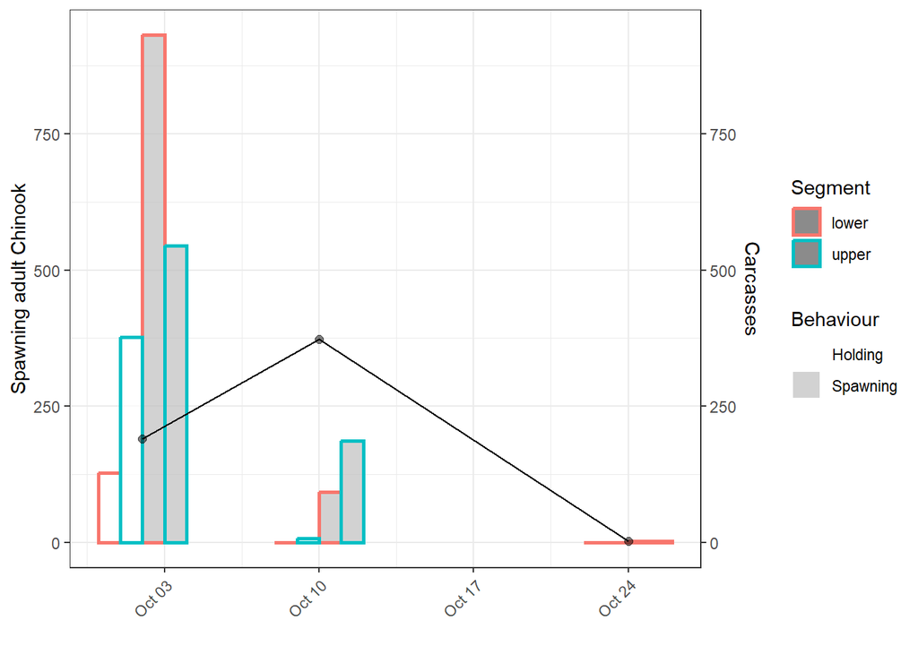

Figure: Expanded live adult Chinook (bars) and carcasses (black line) in the San Juan mainstem. Bar fill colour indicates behaviour (spawning=gray, holding=white) while bar outline colour indicates river segment (lower=pink, mid=green, upper=blue).

## 4.4 Swim & fence counts

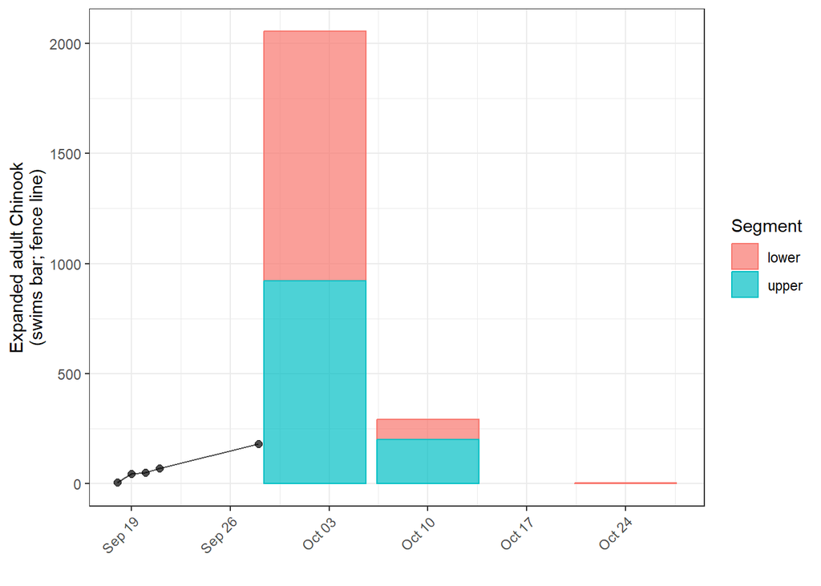

Figure: Chinook swim counts (expanded adults) in the San Juan mainstem relative to cumulative fence counts (black line).

## 4.5 Tributaries

| trib_status | system | date | expanded_live_adults | dead_adults |
| --- | --- | --- | --- | --- |
| Other Area 20 | Gordon River | 2024-10-03 | 72 | 2 |
| San Juan mainstem | San Juan River | 2024-10-02 | 2055 | 190 |
| San Juan mainstem | San Juan River | 2024-10-10 | 292 | 373 |
| San Juan mainstem | San Juan River | 2024-10-24 | 2 | 2 |
| San Juan trib | Harris Creek | 2024-10-07 | 51 | 3 |
| San Juan trib | Lens Creek | 2024-10-09 | 15 | 0 |
| San Juan trib | Renfrew Creek | 2024-10-24 | 9 | 1 |

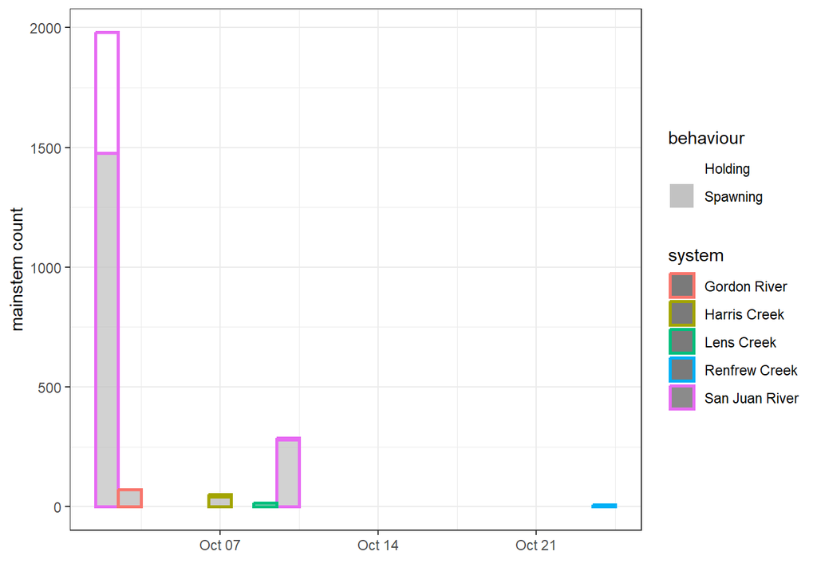

Figure: Mainstem and trib counts for Chinook adults (unexpanded).

## 4.6 Area 20 preliminary escapement estimate (PL+D)

Table: San Juan swim counts (expanded live and dead) and preliminary escapement estimates for three San Juan surveys in 2023.

| ShortSpecies | Section_AreaInspected | SDate | WaterTemperature | WaterClarity | LiveAdults | DeadAdults | LiveJacks | DeadJacks | ExpLiveAdults | ExpDeadAdults | ExpLiveJacks | ExpDeadJacks | OverallReliability | EstPctSeen |
| --- | --- | --- | --- | --- | --- | --- | --- | --- | --- | --- | --- | --- | --- | --- |
| CN | GORDON RIVER | 2024-10-03 | 99.0 | 3 - 5 m or to Bottom | 72 | NA | NA | NA | 72 | NA | NA | NA | H | 1.0 |
| CN | HARRIS CREEK | 2024-10-07 | 9.5 | 3 - 5 m or to Bottom | 51 | NA | 1 | NA | 51 | NA | NA | NA | H | 1.0 |
| CN | LENS CREEK | 2024-10-09 | 10.0 | 3 - 5 m or to Bottom | 15 | NA | NA | NA | 15 | NA | NA | NA | H | 1.0 |
| CN | RENFREW CREEK | 2024-10-24 | 8.0 | 3 - 5 m or to Bottom | 9 | 1 | NA | NA | 9 | NA | NA | NA | M | 1.0 |
| CN | SAN JUAN RIVER | 2024-10-02 | 6.0 | 3 - 5 m or to Bottom | 1980 | 190 | 44 | NA | 2055 | NA | NA | NA | H | 1.0 |
| CN | SAN JUAN RIVER | 2024-10-10 | 9.5 | 3 - 5 m or to Bottom | 287 | 373 | NA | NA | 292 | NA | NA | NA | M | 1.0 |
| CN | SAN JUAN RIVER | 2024-10-25 | 8.0 | 3 - 5 m or to Bottom | 2 | 2 | NA | NA | 7 | NA | NA | NA | M | 0.3 |

Table: Escapement estimates for each system. San Juan mainstem surveys were rolled up based on mid-point date for each of 3 complete survey events, and then the PL+D was selected based on the 3 survey events. **NOTE FINAL SJ CN ESTIMATE DOES NOT YET ACCOUNT FOR REMOVAL OF TRIBUTARY SPAWNERS, THAT MUST BE DONE LATER IN NuSEDS – should be 2642-24-21 = 2597**.

[output not shown]

### 4.6.1 Estimate decision:

For 2024 estimate, went with PL+D (expanded) estimate for SJ. Expanded Oct 25 survey to account for missed Chinook in upper (not surveyed). Did not subtract any trib fish this year as most were spawning on the first peak swim and also spawning when seen in tribs, so it’s very unlikely fish were double-counted on their way to Harris/Lens. Added in broodstock from seining/fence ops.

## 4.7 2024 compared to historical run timing and abundance

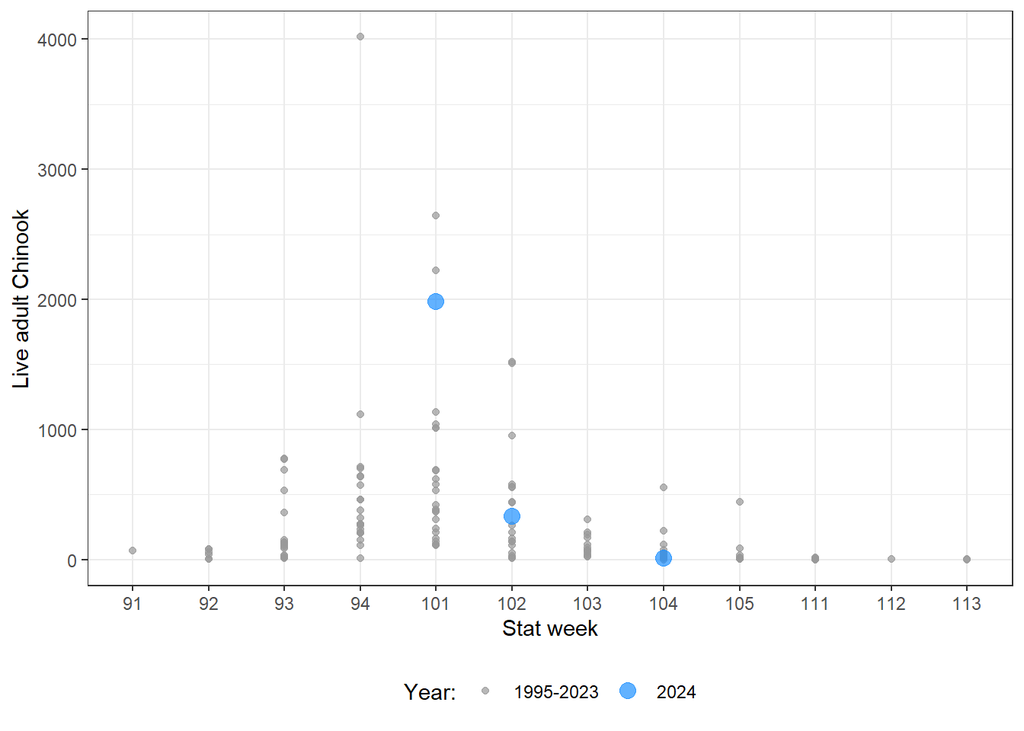

Figure: Raw swim counts (blue) from this year compared to historical raw swim counts. Stat weeks indicate the month (8=August, 12=December) and week of momth (1=first week, 2=2nd week, etc.), e.g., 81=First week of August, 91=First week of September, etc. Mainstem and tributary counts within a statweek are pooled to give run timing for the aggregate system (e.g., SJ + Harris + Lens).

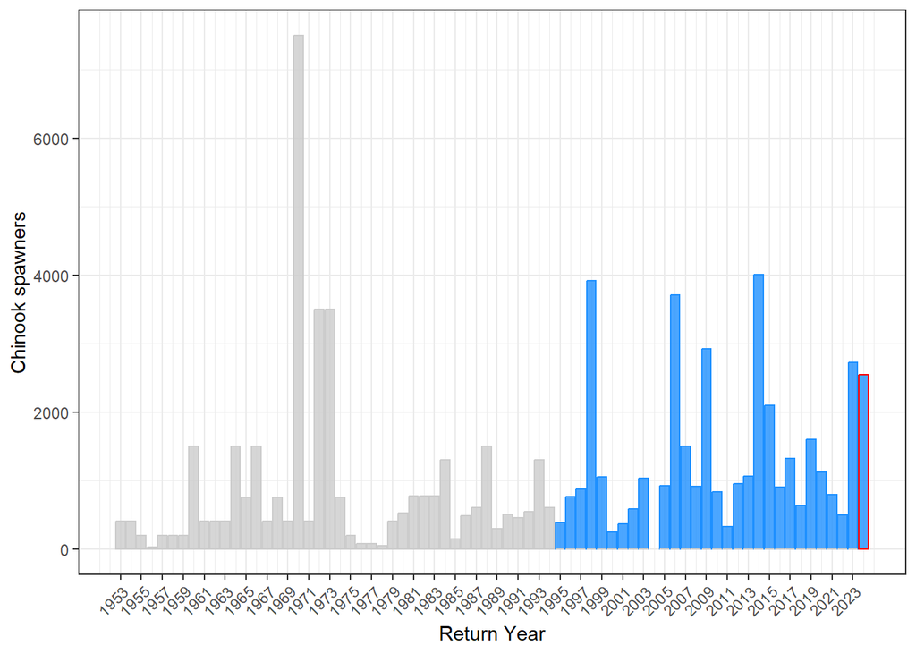

Figure: 2024 preliminary adult Chinook escapement estimate (red outline) relative to historical adult (blue) and unspecified (gray) escapement estimates. Gaps indicate years without estimates.

# 5 **Pink**

## 5.1 Area 20 raw vs expanded counts

Counts are expanded for % population estimated and/or observer efficiency, depending on survey conditions.

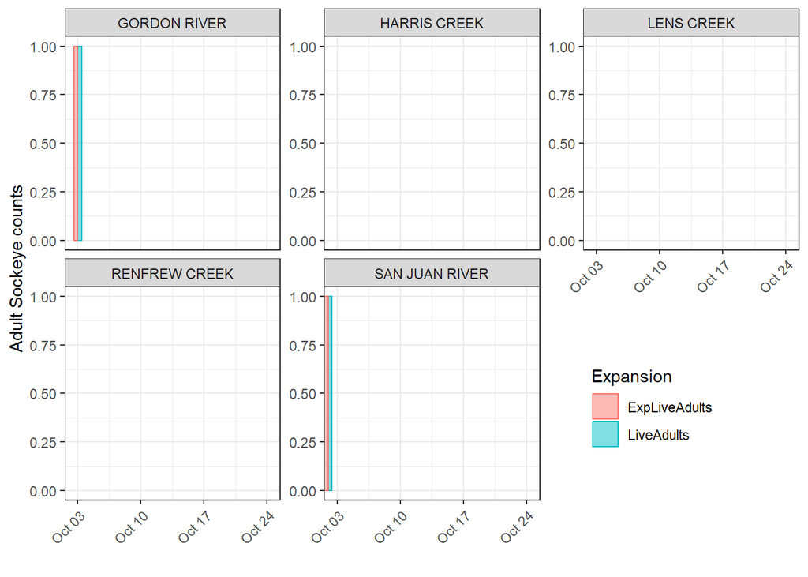

## 5.2 Swim & fence counts

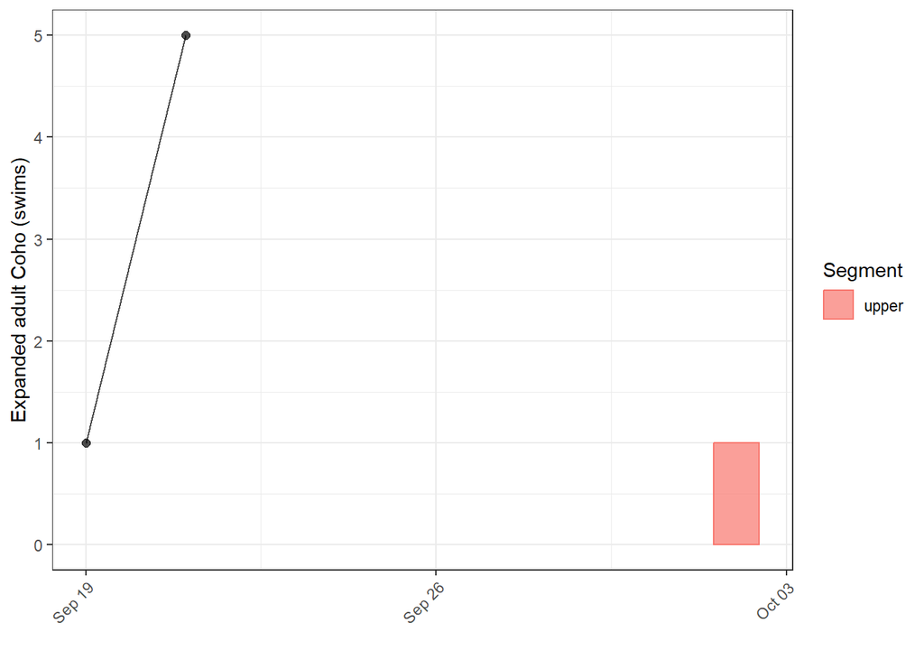

Figure: Pink swim counts (raw adults) in the San Juan mainstem relative to cumulative fence counts (black line). If no black line, then no pink were counted through the fence this year.

## 5.3 Area 20 preliminary escapement estimate (PL+D)

Table: San Juan swim counts (expanded live and dead) and preliminary escapement estimates for San Juan surveys.

| ShortSpecies | Section_AreaInspected | SDate | WaterTemperature | WaterClarity | LiveAdults | DeadAdults | LiveJacks | DeadJacks | ExpLiveAdults | ExpDeadAdults | ExpLiveJacks | ExpDeadJacks | OverallReliability | EstPctSeen |
| --- | --- | --- | --- | --- | --- | --- | --- | --- | --- | --- | --- | --- | --- | --- |
| PK | GORDON RIVER | 2024-10-03 | 99.0 | 3 - 5 m or to Bottom | 1 | NA | NA | NA | 1 | NA | NA | NA | H | 1 |
| PK | HARRIS CREEK | 2024-10-07 | 9.5 | 3 - 5 m or to Bottom | NA | NA | NA | NA | NA | NA | NA | NA | NA | NA |
| PK | LENS CREEK | 2024-10-09 | 10.0 | 3 - 5 m or to Bottom | NA | NA | NA | NA | NA | NA | NA | NA | NA | NA |
| PK | RENFREW CREEK | 2024-10-24 | 8.0 | 3 - 5 m or to Bottom | NA | NA | NA | NA | NA | NA | NA | NA | NA | NA |
| PK | SAN JUAN RIVER | 2024-10-02 | 6.0 | 3 - 5 m or to Bottom | 1 | NA | NA | NA | 1 | NA | NA | NA | H | 1 |
| PK | SAN JUAN RIVER | 2024-10-10 | 9.5 | 3 - 5 m or to Bottom | NA | NA | NA | NA | NA | NA | NA | NA | NA | NA |
| PK | SAN JUAN RIVER | 2024-10-25 | 8.0 | 3 - 5 m or to Bottom | NA | NA | NA | NA | NA | NA | NA | NA | NA | NA |

Table: Escapement estimates for each system. San Juan mainstem surveys were rolled up based on mid-point date for each of 3 complete survey events, and then the PL+D was selected based on the 3 survey events.

| ShortSpecies | SystemName | AdultRawPLD | AdultExpPLD | JackRawPLD | JackExpPLD | AdultRemovalsReco | JackRemovalsReco | FinalAdultEstimate | FinalJackEstimate |
| --- | --- | --- | --- | --- | --- | --- | --- | --- | --- |
| PK | San Juan River | 1 | 1 | 0 | 0 | 0 | 0 | 5 | 0 |
| PK | Renfrew Creek | 0 | 0 | 0 | 0 | 0 | 0 | 0 | 0 |
| PK | Harris Creek | 0 | 0 | 0 | 0 | 0 | 0 | 0 | 0 |
| PK | Lens Creek | 0 | 0 | 0 | 0 | 0 | 0 | 0 | 0 |
| PK | Gordon River | 1 | 1 | 0 | 0 | 0 | 0 | 1 | 0 |

### 5.3.1 Estimate decision:

For 2024 estimate used fence count for SJ mainstem and PL+D for Gordon. *This is subject to change; see EscBatchHardCopy report for specific estimate abundance.*

## 5.4 2024 compared to historical abundance

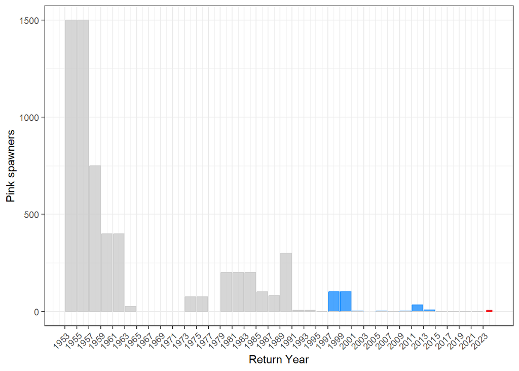

Figure: 2024 preliminary adult Pink escapement estimate (red outline) relative to historical adult (blue) and unspecified (gray) escapement estimates. Gaps indicate years without estimates.